# STAT 302 Final Presentation: Health Issues in Chinatown

## Overview of Data

For this project, I used “PLACES: Local Data for Better Health” datasets to investigate health issues in Chicago’s Chinatown. This data collection project is an extension of the 500 Cities Project conducted from 2016-2019 by the CDC, CDC Foundation, and Robert Wood Johnson Foundation, which investigated 27 chronic disease measures for the 500 largest American cities.

This extension project began in 2019 with releases occurring annually from 2020. This project utilized all three releases of data organized by ZCTA, focusing on the 60616 zip code. Linked below are the source to each dataset as a citation:

- [PLACES 2020](https://chronicdata.cdc.gov/500-Cities-Places/PLACES-Local-Data-for-Better-Health-ZCTA-Data-2020/fbbf-hgkc)
- [PLACES 2021](https://chronicdata.cdc.gov/500-Cities-Places/PLACES-Local-Data-for-Better-Health-ZCTA-Data-2021/s85h-9xpy)
- [PLACES 2022](https://chronicdata.cdc.gov/500-Cities-Places/PLACES-Local-Data-for-Better-Health-ZCTA-Data-2022/qnzd-25i4)

[figure not shown]

## Why this Data

I am part of a club called Chinatown Health Initiative, and one of the projects my sub-committee hopes to complete this year is a data science initiative to learn more about the health issues that Chinatown residents face most frequently. I therefore selected this dataset to begin this club project. ZCTA data was chosen over county and city data to increase specificity of the region of study.

## Prevalence of Disease

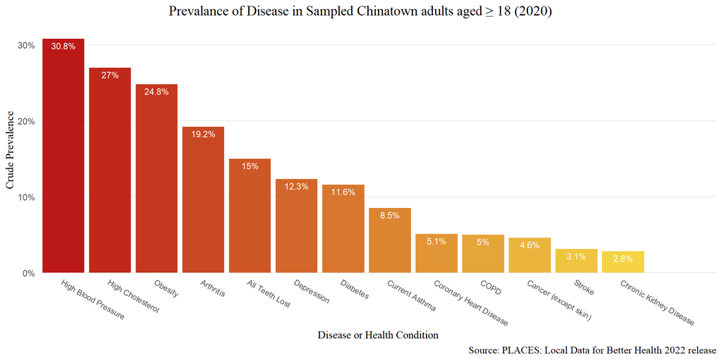

## Change in Risk Behaviors

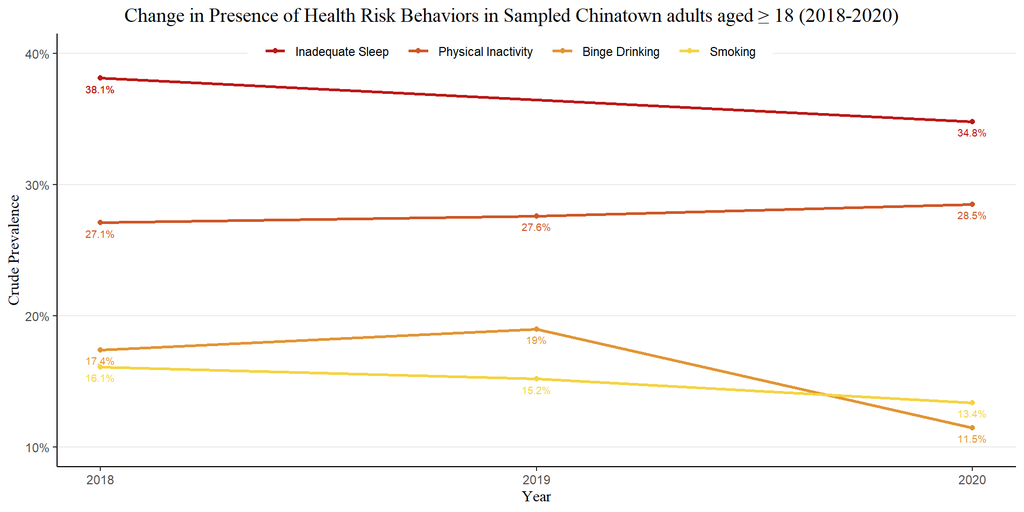

## Comparison to Chicagoland

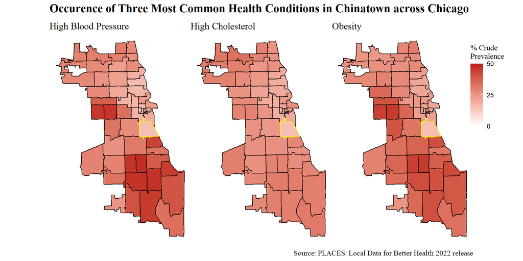

Chinatown is highlighted with a yellow border. Comparison maps for the remaining diseases for which survey data is available can be generated with the linked Shiny dashboard. [Click here to access dashboard](https://9iuyod-hannah-ma.shinyapps.io/map_dashboard/).